# GAMs for binary outcomes (mgcv)

Biostatistics 735/794 — Machine Learning in Public Health (R)

Alexander

September 16, 2025

```r
options(rmarkdown.files.suffix = "_rmdfiles")
# Core
library(tidyverse)
library(rsample)
library(yardstick)
library(broom)
library(knitr)
library(kableExtra)

# Modeling
library(mgcv)      # gam()
library(recipes)   # optional preprocessing for CV folds
```

# Loading in the data

We’ll use the same Wisconsin Diagnostic Breast Cancer (WDBC) data as last time. Each row is a patient. Outcome Diagnosis is Benign or Malignant. Predictors are 30 numeric features derived from FNA images.

```r
# Download from UCI ML repo
  url_data  <- "https://archive.ics.uci.edu/ml/machine-learning-databases/breast-cancer-wisconsin/wdbc.data"
  raw <- read.csv(url_data, header = FALSE)


# According to UCI:
# V1 = ID, V2 = Diagnosis (M/B), V3:V32 = 30 features
names(raw) <- c("ID","Diagnosis",
                "radius_mean","texture_mean","perimeter_mean","area_mean","smoothness_mean",
                "compactness_mean","concavity_mean","concave_points_mean","symmetry_mean","fractal_dimension_mean",
                "radius_se","texture_se","perimeter_se","area_se","smoothness_se",
                "compactness_se","concavity_se","concave_points_se","symmetry_se","fractal_dimension_se",
                "radius_worst","texture_worst","perimeter_worst","area_worst","smoothness_worst",
                "compactness_worst","concavity_worst","concave_points_worst","symmetry_worst","fractal_dimension_worst")

bc <- raw %>%
  as_tibble() %>%
  mutate(Diagnosis = factor(Diagnosis, levels = c("B","M"))) %>%  # B=negative (benign), M=positive (malignant)
  select(-ID)

glimpse(bc)
```

```
## Rows: 569
## Columns: 31
## $ Diagnosis               <fct> M, M, M, M, M, M, M, M, M, M, M, M, M, M, M, M…
## $ radius_mean             <dbl> 17.990, 20.570, 19.690, 11.420, 20.290, 12.450…
## $ texture_mean            <dbl> 10.38, 17.77, 21.25, 20.38, 14.34, 15.70, 19.9…
## $ perimeter_mean          <dbl> 122.80, 132.90, 130.00, 77.58, 135.10, 82.57, …
## $ area_mean               <dbl> 1001.0, 1326.0, 1203.0, 386.1, 1297.0, 477.1, …
## $ smoothness_mean         <dbl> 0.11840, 0.08474, 0.10960, 0.14250, 0.10030, 0…
## $ compactness_mean        <dbl> 0.27760, 0.07864, 0.15990, 0.28390, 0.13280, 0…
## $ concavity_mean          <dbl> 0.30010, 0.08690, 0.19740, 0.24140, 0.19800, 0…
## $ concave_points_mean     <dbl> 0.14710, 0.07017, 0.12790, 0.10520, 0.10430, 0…
## $ symmetry_mean           <dbl> 0.2419, 0.1812, 0.2069, 0.2597, 0.1809, 0.2087…
## $ fractal_dimension_mean  <dbl> 0.07871, 0.05667, 0.05999, 0.09744, 0.05883, 0…
## $ radius_se               <dbl> 1.0950, 0.5435, 0.7456, 0.4956, 0.7572, 0.3345…
## $ texture_se              <dbl> 0.9053, 0.7339, 0.7869, 1.1560, 0.7813, 0.8902…
```

[output cut: 18 more lines]

```r
summary(bc$Diagnosis)
```

```
##   B   M
## 357 212
```

Train/test split (stratified):

```r
set.seed(42)
split <- initial_split(bc, prop = 0.8, strata = Diagnosis)
train <- training(split)
test  <- testing(split)

nrow(train); nrow(test)
```

```
## [1] 454
```

```
## [1] 115
```

Note: mgcv::gam() can handle predictors on their original scale. Standardization is not required, but we’ll use the same recipe within CV folds to avoid leakage when needed.

Optional base recipe for CV folds (zero-variance removal + standardization):

```r
  rec_base <- recipe(Diagnosis ~ ., data = train) %>%
  step_zv(all_predictors()) %>%
  step_normalize(all_predictors())
```

⸻

# Baseline GLM vs. GAM (smooths on key predictors)

```r
# Choose a compact set to make plots readable (you can expand later)
core_vars <- c("radius_mean","texture_mean","perimeter_mean","area_mean",
               "smoothness_mean","concavity_mean","concave_points_mean")

form_glm <- as.formula(
  paste("Diagnosis ~", paste(core_vars, collapse = " + "))
)

form_gam <- Diagnosis ~
  s(radius_mean, k = 10) +
  s(texture_mean, k = 10) +
  s(perimeter_mean, k = 10) +
  s(area_mean, k = 10) +
  s(smoothness_mean, k = 10) +
  s(concavity_mean, k = 10) +
  s(concave_points_mean, k = 10)

form_gam_te <- Diagnosis ~
  s(radius_mean, k = 10) +
  s(area_mean, k = 10) +
  te(radius_mean, area_mean, k = c(10,10)) +   # smooth interaction surface
  s(texture_mean, k = 10) +
  s(perimeter_mean, k = 10) +
  s(smoothness_mean, k = 10) +
  s(concavity_mean, k = 10) +
  s(concave_points_mean, k = 10)

# Fit on training data
glm_fit <- glm(form_glm, data = train, family = binomial())
gam_fit <- gam(form_gam, data = train, family = binomial(), method = "REML")
gam_te_fit <- gam(form_gam_te, data = train, family = binomial(), method = "REML")

-logLik(glm_fit)
```

```
## 'log Lik.' 62.27839 (df=8)
```

```r
summary(gam_fit)$sp.criterion[1]   # REML score
```

```
##     REML
## 44.31101
```

```r
summary(gam_te_fit)$sp.criterion[1]
```

```
##     REML
## 42.28213
```

Basic diagnostics for the GAM:

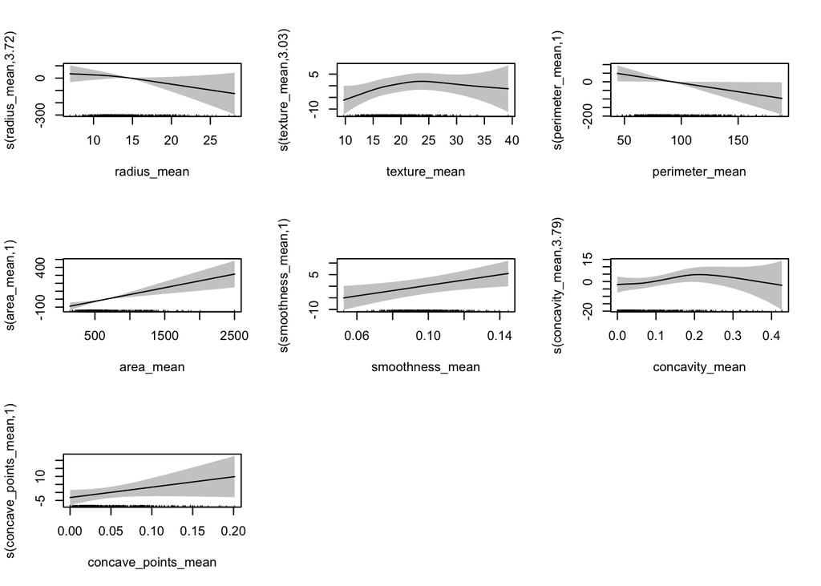

```r
  par(mfrow = c(2,3))
plot(gam_fit, pages = 1, shade = TRUE, seWithMean = TRUE, rug = TRUE, scale = 0)
```

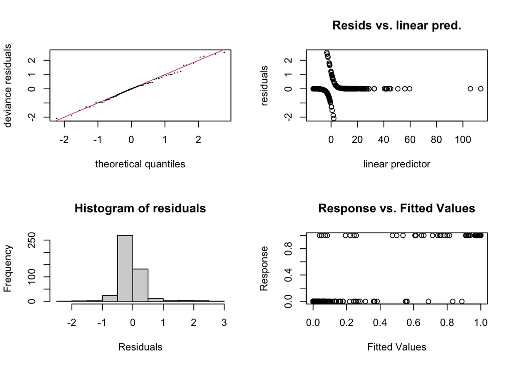

```
##
## Method: REML   Optimizer: outer newton
## full convergence after 13 iterations.
## Gradient range [-4.945257e-05,5.389351e-06]
## (score 44.31101 & scale 1).
## Hessian positive definite, eigenvalue range [1.00219e-06,1.157487].
## Model rank =  64 / 64
##
## Basis dimension (k) checking results. Low p-value (k-index<1) may
## indicate that k is too low, especially if edf is close to k'.
##
##                          k'  edf k-index p-value
## s(radius_mean)         9.00 3.72    0.99   0.415
## s(texture_mean)        9.00 3.03    1.01   0.675
## s(perimeter_mean)      9.00 1.00    1.02   0.690
## s(area_mean)           9.00 1.00    0.95   0.170
## s(smoothness_mean)     9.00 1.00    0.96   0.235
## s(concavity_mean)      9.00 3.79    0.90   0.025 *
## s(concave_points_mean) 9.00 1.00    1.03   0.835
## ---
## Signif. codes:  0 '***' 0.001 '**' 0.01 '*' 0.05 '.' 0.1 ' ' 1
```

```r
par(mfrow = c(1,1))
gam.check(gam_fit)  # k-index, residuals, etc.
```

### Interpreting the `gam.check()` Table

The `gam.check()` output includes a table with columns like:

- **k’**: the basis dimension you set in `s(x, k=…)`. This is the *maximum* wiggliness allowed.
- **edf** (effective degrees of freedom): how complex the fitted smooth actually is.
  - edf ≈ 1 → the effect is nearly linear.
  - edf > 1 → evidence of a nonlinear relationship.
- **k-index**: checks whether the chosen `k` was large enough.
  - Close to 1 → fine.
  - Much lower than 1 → the model wanted more wiggle; `k` may be too small.
- **p-value**: test of whether increasing `k` would improve the fit.
  - Small p-value (< 0.05) → increase `k` for that smooth.
  - Large p-value → current basis dimension is likely adequate.

**Rule of thumb**:  
If the *k-index is low* **and** the *p-value is small*, refit with a larger `k`. Otherwise, your choice of `k` is probably fine.

⸻

# Hold-out performance (AUC, sensitivity, specificity, NPV)

Predict on test set and compare GLM vs. GAM(s).

Helper: compute metrics at a fixed threshold (e.g., 0.5); AUC is threshold-free

```r
eval_bin <- function(df_truth, probs, thr = 0.5) {
  cls <- factor(ifelse(probs >= thr, "M","B"), levels = levels(df_truth))
  tibble(
    AUC  = roc_auc_vec(df_truth, probs, event_level = "second"),
    Sens = sens_vec(df_truth, cls, event_level = "second"),
    Spec = spec_vec(df_truth, cls, event_level = "second"),
    NPV  = npv_vec (df_truth, cls, event_level = "second")
  )
}

p_test_glm   <- predict(glm_fit, newdata = test, type = "response")
p_test_gam   <- predict(gam_fit, newdata = test, type = "response")
p_test_gamte <- predict(gam_te_fit, newdata = test, type = "response")

bind_rows(
  eval_bin(test$Diagnosis, p_test_glm)   %>% mutate(Model = "GLM (linear)"),
  eval_bin(test$Diagnosis, p_test_gam)   %>% mutate(Model = "GAM (additive)"),
  eval_bin(test$Diagnosis, p_test_gamte) %>% mutate(Model = "GAM (additive + tensor)")
) %>%
  relocate(Model) %>%
  kable(digits = 3, caption = "Hold-out performance (threshold = 0.5)") %>%
  kable_styling(full_width = FALSE)
```

Hold-out performance (threshold = 0.5)

| Model | AUC | Sens | Spec | NPV |
| --- | --- | --- | --- | --- |
| GLM (linear) | 0.992 | 0.884 | 0.972 | 0.933 |
| GAM (additive) | 0.997 | 0.953 | 0.986 | 0.973 |
| GAM (additive + tensor) | 0.989 | 0.953 | 0.986 | 0.973 |

ROC curves:

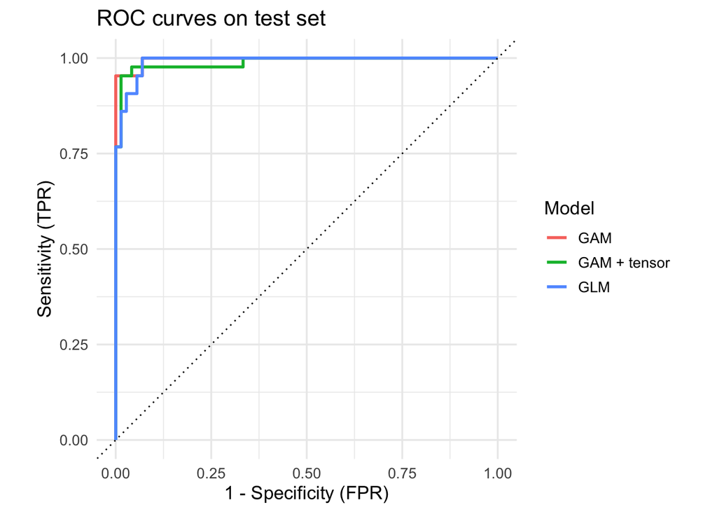

```r
ROC_data_test <- test %>%
  mutate(
    estimate_glm = p_test_glm,
    estimate_gam = p_test_gam,
    estimate_gamte = p_test_gamte
    )

  roc_tbl <- bind_rows(
    yardstick::roc_curve(data = ROC_data_test,
                         Diagnosis, estimate_glm,
                         event_level = "second") %>%
      mutate(Model = "GLM"),
    yardstick::roc_curve(data = ROC_data_test,
                         Diagnosis, estimate_gam,
                         event_level = "second") %>%
      mutate(Model = "GAM"),
    yardstick::roc_curve(data = ROC_data_test,
                         Diagnosis, estimate_gamte,
                         event_level = "second") %>%
      mutate(Model = "GAM + tensor")
  )


ggplot(roc_tbl, aes(x = 1 - specificity, y = sensitivity, color = Model)) +
  geom_path(size = 1) +
  geom_abline(slope = 1, intercept = 0, linetype = 3) +
  coord_equal() +
  labs(title = "ROC curves on test set", x = "1 - Specificity (FPR)", y = "Sensitivity (TPR)") +
  theme_minimal(base_size = 13)
```

⸻

# CV selection among GLM and GAM candidates (by AUC)

We’ll do 10-fold stratified CV. Within each fold we’ll optionally standardize predictors via a recipe, fit competing models, and compute AUC on the validation partition.

```r
set.seed(202)
folds <- vfold_cv(train, v = 10, strata = Diagnosis)

# Fold-wise evaluator for a provided fit function
cv_eval <- function(folds, base_recipe, fit_fun, pred_type = c("response","link")) {
  pred_type <- match.arg(pred_type)
  map_dfr(seq_len(nrow(folds)), function(i){
    sp <- folds$splits[[i]]
    tr <- analysis(sp); va <- assessment(sp)

    # fold-specific preprocessing
    rec <- prep(base_recipe, training = tr)
    trx <- bake(rec, tr)
    vax <- bake(rec, va)

    fit <- fit_fun(trx)
    p   <- predict(fit, newdata = vax, type = pred_type)
    # mgcv::predict returns numeric probs for binomial when type="response"
    tibble(fold = i, AUC = roc_auc_vec(vax$Diagnosis, p, event_level = "second"))
  }) %>% summarise(AUC_mean = mean(AUC), AUC_sd = sd(AUC))
}

fit_glm_fun <- function(dat) glm(form_glm, data = dat, family = binomial())
fit_gam_fun <- function(dat) gam(form_gam, data = dat, family = binomial(), method = "REML")
fit_gamte_fun <- function(dat) gam(form_gam_te, data = dat, family = binomial(), method = "REML")

cv_glm   <- cv_eval(folds, rec_base, fit_glm_fun,   pred_type = "response")
cv_gam   <- cv_eval(folds, rec_base, fit_gam_fun,   pred_type = "response")
cv_gamte <- cv_eval(folds, rec_base, fit_gamte_fun, pred_type = "response")
bind_rows(
  cv_glm   %>% mutate(Model = "GLM"),
  cv_gam   %>% mutate(Model = "GAM"),
  cv_gamte %>% mutate(Model = "GAM + tensor")
) %>% relocate(Model) %>%
  kable(digits = 3, caption = "10-fold CV by AUC (training folds only)") %>%
  kable_styling(full_width = FALSE)
```

10-fold CV by AUC (training folds only)

| Model | AUC_mean | AUC_sd |
| --- | --- | --- |
| GLM | 0.982 | 0.021 |
| GAM | 0.987 | 0.015 |
| GAM + tensor | 0.974 | 0.043 |

⸻

# Automatic smooth selection (`select=TRUE`) and concurvity check

`mgcv` can shrink smooths to zero if they’re not helpful (`select=TRUE`), similar in spirit to feature selection.  
This adds an extra penalty to each term so that the smoothing parameter estimation can *essentially* remove terms from the model.

```r
form_gam_sel <- Diagnosis ~
  s(radius_mean, k = 10) +
  s(texture_mean, k = 10) +
  s(perimeter_mean, k = 10) +
  s(area_mean, k = 10) +
  s(smoothness_mean, k = 10) +
  s(concavity_mean, k = 10) +
  s(concave_points_mean, k = 10)

gam_sel <- gam(form_gam_sel, data = train, family = binomial(), method = "REML", select = TRUE)
summary(gam_sel)
```

```
##
## Family: binomial
## Link function: logit
##
## Formula:
## Diagnosis ~ s(radius_mean, k = 10) + s(texture_mean, k = 10) +
##     s(perimeter_mean, k = 10) + s(area_mean, k = 10) + s(smoothness_mean,
##     k = 10) + s(concavity_mean, k = 10) + s(concave_points_mean,
##     k = 10)
##
## Parametric coefficients:
##             Estimate Std. Error z value Pr(>|z|)
## (Intercept)  -0.6735     0.2976  -2.263   0.0236 *
## ---
## Signif. codes:  0 '***' 0.001 '**' 0.01 '*' 0.05 '.' 0.1 ' ' 1
##
## Approximate significance of smooth terms:
##                              edf Ref.df Chi.sq  p-value
## s(radius_mean)         6.491e-06      9  0.000  0.60167
## s(texture_mean)        2.611e+00      9 26.551 5.44e-07 ***
## s(perimeter_mean)      3.182e-05      9  0.000  0.15573
## s(area_mean)           9.640e-01      9 22.932  < 2e-16 ***
## s(smoothness_mean)     8.920e-01      9  7.185  0.00213 **
## s(concavity_mean)      1.553e+00      9  3.981  0.04358 *
## s(concave_points_mean) 7.675e-01      9  2.805  0.02937 *
## ---
## Signif. codes:  0 '***' 0.001 '**' 0.01 '*' 0.05 '.' 0.1 ' ' 1
##
## R-sq.(adj) =  0.836   Deviance explained = 80.9%
## -REML = 69.891  Scale est. = 1         n = 454
```

```r
# Concurvity (nonlinear analogue of multicollinearity)
conc <- concurvity(gam_sel, full = TRUE)
conc[3,-1] %>%
  as_tibble(rownames = "term") %>%
  arrange(desc(value)) %>%
  head(10) %>%
  kable(digits = 3, caption = "Top concurvity estimates (higher = more problematic)") %>%
  kable_styling(full_width = FALSE)
```

Top concurvity estimates (higher = more problematic)

| term | value |
| --- | --- |
| s(radius_mean) | 0.999 |
| s(perimeter_mean) | 0.996 |
| s(area_mean) | 0.996 |
| s(concave_points_mean) | 0.927 |
| s(concavity_mean) | 0.858 |
| s(smoothness_mean) | 0.540 |
| s(texture_mean) | 0.216 |

⸻

# Partial effect visualization (smooths) and 2D interaction surface

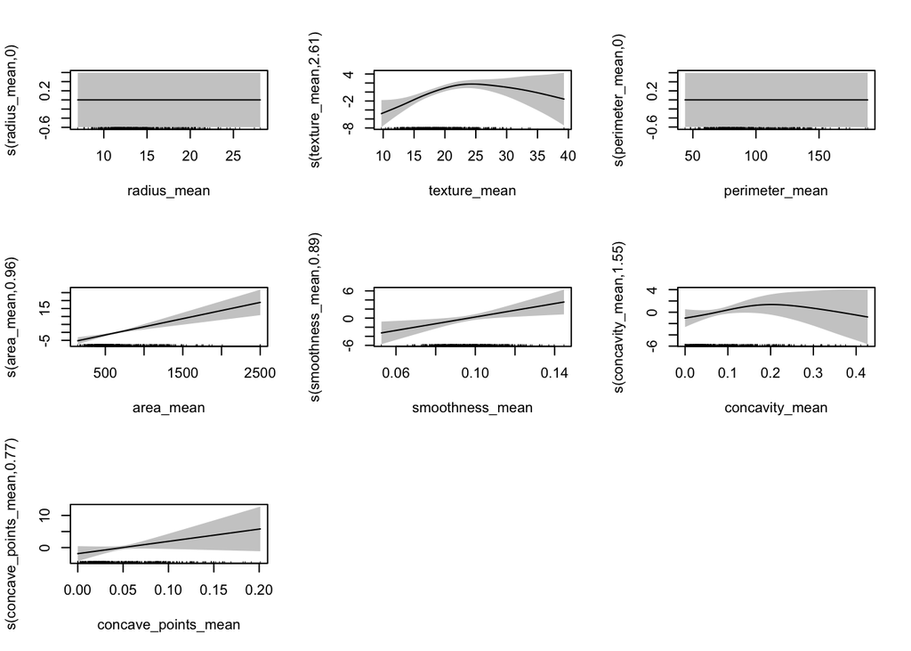

```r
par(mfrow = c(2,3))
plot(gam_sel, pages = 1, shade = TRUE, seWithMean = TRUE, rug = TRUE, scale = 0)
```

```r
par(mfrow = c(1,1))
```

2D surface for the tensor interaction (if using the gam_te_fit):

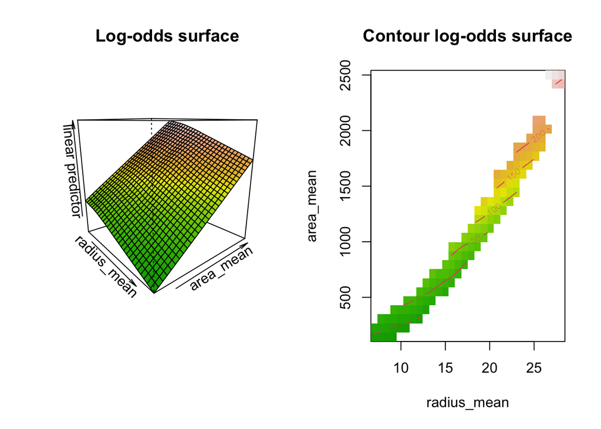

```r
par(mfrow = c(1,2))
  vis.gam(gam_te_fit, view = c("radius_mean","area_mean"),
          color = "terrain", theta = 50,
          main = "Log-odds surface")
vis.gam(gam_te_fit, view = c("radius_mean","area_mean"),
          plot.type = "contour", color = "terrain", too.far = 0.05,
          main = "Contour log-odds surface")
```

```r
summary(gam_te_fit)$s.table %>%
  kable(digits = 3, caption = "Summary of smooth terms in the GAM + tensor model.") %>%
  kable_styling(full_width = FALSE)
```

Summary of smooth terms in the GAM + tensor model.

|  | edf | Ref.df | Chi.sq | p-value |
| --- | --- | --- | --- | --- |
| s(radius_mean) | 2.551 | 2.734 | 3.861 | 0.232 |
| s(area_mean) | 1.000 | 1.000 | 12.756 | 0.000 |
| te(radius_mean,area_mean) | 6.875 | 51.000 | 14.290 | 0.002 |
| s(texture_mean) | 3.688 | 4.585 | 16.676 | 0.003 |
| s(perimeter_mean) | 1.000 | 1.000 | 4.464 | 0.035 |
| s(smoothness_mean) | 2.092 | 2.578 | 6.319 | 0.056 |
| s(concavity_mean) | 3.673 | 4.541 | 8.596 | 0.099 |
| s(concave_points_mean) | 1.000 | 1.000 | 2.900 | 0.089 |

⸻

# Calibrated threshold via Youden’s J (optional)

Pick a probability threshold on the training set (Youden’s J) and evaluate on the test set for the chosen GAM.

```r
tune_threshold_j <- function(truth, prob, grid = seq(0.01, 0.99, by = 0.01)) {
  stopifnot(is.factor(truth), length(levels(truth)) == 2)
  best_thr <- 0.5; best_j <- -Inf
  for (t in grid) {
    cls <- factor(ifelse(prob >= t, levels(truth)[2], levels(truth)[1]),
                  levels = levels(truth))
    se <- sens_vec(truth, cls, event_level = "second")
    sp <- spec_vec(truth, cls, event_level = "second")
    j  <- as.numeric(se + sp - 1)
    if (!is.na(j) && j > best_j) { best_j <- j; best_thr <- t }
  }
  best_thr
}

p_tr_gam <- predict(gam_sel, newdata = train, type = "response")
thr_gam  <- tune_threshold_j(train$Diagnosis, p_tr_gam)

p_te_gam <- predict(gam_sel, newdata = test, type = "response")
cls_te   <- factor(ifelse(p_te_gam >= thr_gam, "M","B"), levels = levels(test$Diagnosis))

tibble(
  Model = "GAM (select=TRUE)",
  Threshold = thr_gam,
  Test_AUC  = roc_auc_vec(test$Diagnosis, p_te_gam, event_level = "second"),
  Test_Sens = sens_vec(test$Diagnosis, cls_te,    event_level = "second"),
  Test_Spec = spec_vec(test$Diagnosis, cls_te,    event_level = "second"),
  Test_NPV  = npv_vec (test$Diagnosis, cls_te,    event_level = "second")
) %>% kable(digits = 3, caption = "GAM test performance at Youden-tuned threshold")
```

GAM test performance at Youden-tuned threshold

| Model | Threshold | Test_AUC | Test_Sens | Test_Spec | Test_NPV |
| --- | --- | --- | --- | --- | --- |
| GAM (select=TRUE) | 0.49 | 0.997 | 0.93 | 0.986 | 0.959 |

⸻

Takeaways

• GAMs extend logistic regression by allowing smooth, nonlinear effects while keeping an additive structure.

• Tensor smooths (te()) capture interactions as smooth surfaces.

• Use REML (default here) for smoothness selection; select=TRUE can also shrink unhelpful smooths to zero.

• For model choice, prefer CV AUC; for deployment, tune a decision threshold (e.g., via Youden’s J) aligned with clinical goals.